# Ford GoBike Data Analysis

## by Marwan Tafweek

## Investigation Overview

> We want to find the realtionship between different types of data, what affects the trip duration, does the user type depends on the age of the users ?

## Dataset Overview

> this data is defined as  
> duration_sec : Trip duration in seconds  
> start_time : Trip start time  
> end_time : Trip end time  
> start_station_id : The start station ID  
> start_station_name : Start station name  
> end_station_id : The End station ID  
> end_station_name : Start station name  
> bike_id : Bike ID  
> user_type : Type of user ( Customer or Subscriber )  
> member_birth_year : Birth year of the user  
> member_gender : Gender of the user

## Number of Subscribers to Customers

> We can see that the subscribers are way more than non subscribers.

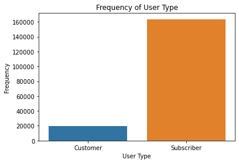

## The age of most of the users

> Most of thd users are born from 1980 to 1990

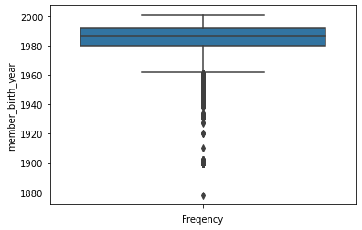

## Relationship between gender of the user and trip duration

> Others are more likely to spend more time in the trip

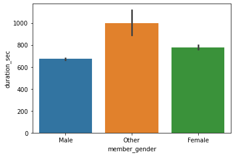

## the relation between trip duration with user type and gender

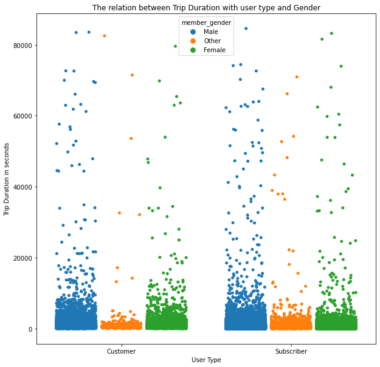